# Numbers

Session 6

Ayush Patel

National Law School of India University, Bengaluru

21 Jul, 2026

# Random Process

> An event for which all possible outcomes are known but it is uncertain which particular outcome will occur.

# Probability

> The proportion of occurrences of an outcome of a random process observed over a large number of observations.

Why large number of observation?

# Basic Probability Rules

## 1. Foundations

- Sample space (S): all possible outcomes
- Event (A): any subset of S
- $0 \le P(A) \le 1$
- $P(S) = 1$

**Example:** Rolling a die, $S = \{1,2,3,4,5,6\}$, $P(\text{rolling a 4}) = \frac{1}{6}$

## 2. Complement Rule

$P(A^c) = 1 - P(A)$

**Example:** $P(\text{not rolling a 6}) = 1 - \frac{1}{6} = \frac{5}{6}$

## 3. Addition Rule (OR)

General: $P(A \cup B) = P(A) + P(B) - P(A \cap B)$

Mutually exclusive: $P(A \cup B) = P(A) + P(B)$

**Example:** Drawing a card, $P(\text{King or Heart}) = \frac{4}{52} + \frac{13}{52} - \frac{1}{52} = \frac{16}{52}$

## 4. Conditional Probability

$P(A \mid B) = \frac{P(A \cap B)}{P(B)}$

**Example:** $P(\text{sum} = 8 \mid \text{first die} = 3) = \frac{1}{6}$ (only need second die = 5)

## 5. Multiplication Rule (AND)

General: $P(A \cap B) = P(A) \cdot P(B \mid A)$

Independent: $P(A \cap B) = P(A) \cdot P(B)$

**Example:** Two coin flips, $P(\text{H then H}) = \frac{1}{2} \cdot \frac{1}{2} = \frac{1}{4}$

## 6. Independence

$P(A \mid B) = P(A) \quad \text{and} \quad P(B \mid A) = P(B)$

Independent ≠ mutually exclusive — mutually exclusive events are actually maximally *dependent* (one rules out the other).

**Example:** Two separate coin tosses are independent; rolling a 3 and rolling a 4 on the *same* die are mutually exclusive, not independent.

## 7. Bayes’ Rule

$P(A \mid B) = \frac{P(B \mid A)\,P(A)}{P(B)}$

**Example:** 1% have a disease. Test is 99% sensitive, 5% false-positive rate.

$P(\text{Disease} \mid +) = \frac{0.99 \times 0.01}{0.99\times 0.01 + 0.05\times 0.99} \approx 0.167$

## Quick Reference Table

| Rule | Formula |
| --- | --- |
| Complement | $P(A^c) = 1 - P(A)$ |
| Addition (general) | $P(A \cup B) = P(A) + P(B) - P(A \cap B)$ |
| Addition (exclusive) | $P(A \cup B) = P(A) + P(B)$ |
| Conditional | $P(A \mid B) = \frac{P(A \cap B)}{P(B)}$ |
| Multiplication (general) | $P(A \cap B) = P(A) \cdot P(B \mid A)$ |
| Multiplication (independent) | $P(A \cap B) = P(A) \cdot P(B)$ |
| Bayes’ Rule | $P(A \mid B) = \frac{P(B \mid A)\,P(A)}{P(B)}$ |

# Probability Distribution

1. The sample distribution is not an accurate picture of population distribution
2. We need a way to arrive at a reasonable estimate of the probability of outcomes in population using sample data
3. If the sample is representative, we can estimate the probability distribution of a random process. This distribution is called the probability distribution.

# Random Variable

> The outcomes of a Random Process can be assigned with a value. Recordings of the values of the outcomes of a random process is called a Random Variable

There can be discrete or continuous random variables.

## Probability Distribution of discrete random variables

For an outcome space of a random process A, defined as $A = \{a| a \space is \space number \space of \space instagram followers\}$

$0 <= P(a) <= 1$ and $\sum_{i =1}^{|A|}{P(a_i)} = 1$

## Car Ownership

A survey is given to all of section E students. With only one question. Number of cars owned by their HH. Following is the summary table:

| Number of Cars owned (N) | Total HH that own N cars | % of HH that own N cars |
| --- | --- | --- |
| 0 | 4 | 5.7% |
| 1 | 27 | 38.6% |
| 2 | 18 | 25.7% |
| 3 | 15 | 21.4% |
| 4 | 6 | 8.6 % |

## Car Ownership

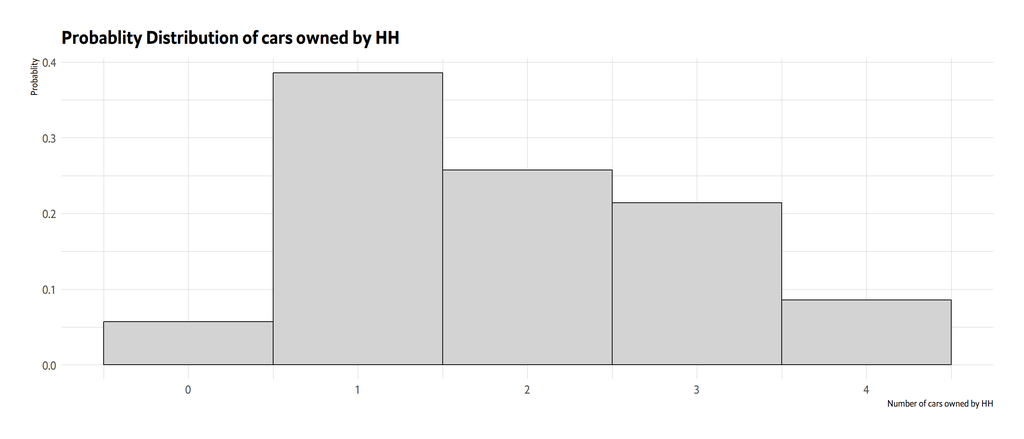

## Probability Distribution of a continious random variable

1. The outcome space of a continious random variable can be infinite. Ex: Weight of all elephants. Note the range may be finte, but the outcome space can be infinite.
2. So, we must use intervals of a continious random variable to estimate probablity at a point. Say you want probability of the value 3420. So we estiate the probablity of the interval 3420 - a very tiny number to 3420 + a very tiny number. This is done using calculating the area under the cure.

# An intuitive tour of distributions

> [Seeing Theory Chapter 3](https://seeing-theory.brown.edu/#secondPage/chapter3) without the central limit theorm

# Review Questions

1. Agresti Ch4, question 4.3
2. Agresti Ch4, question 4.4
3. Introductory Stats Ch4, 4.4tryit
4. Introductory Stats Ch4, 4.5tryit5

# Law of Large Numbers

> If a random process or a chance event is repeated for a large number of times the difference between the theoritical probablity distribution and the observed relative frequency distribution approaches to zero.

## Law of Large Numbers

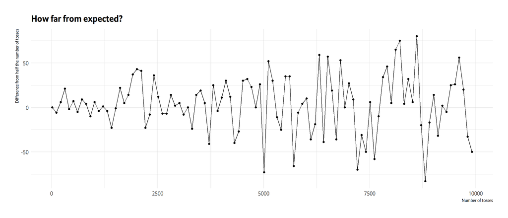

Figure 1: Chance Error

## Law of Large Numbers

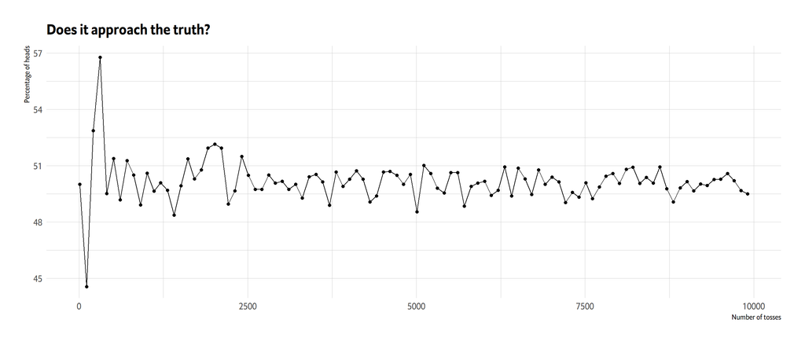

Figure 2

## Law of Large Numbers

1. A machine has been designed to toss a coin automatically and keep track of the number of heads. After 1,000 tosses, it has 550 heads. Express the chance error both in absolute terms and as a percentage of the number of tosses.
2. A coin is tossed 100 times, landing heads 53 times. However, the last seven tosses are all heads. True or false: the chance that the next toss will be heads is somewhat less than 50%. Explain.

# Expected value

> It is the value around which all outcomes of a random process cluster when carried out for a long time.

It is the mean of the population probablity distribution.

# More Normal Stuff

> The normal distribution needs more attention because we find many naturally occurring numbers take this shape and because it is very useful for statistical inference.

The mean of the theoritical/population Normal distribution is represented by $\mu$, and the standard deviation is represented by $\sigma$. These are called populaiton parameters or parameters.

## More Normal Stuff

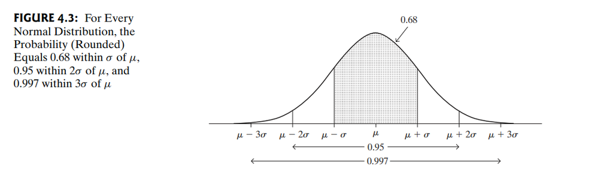

From the Agresti Bbook

Remember, if you take z-score or z-transform a normal distribution, you have a standard normal distribution on your hands.

# Sampling Distribution of Mean

> From a popluation, if multiple samples of same size are taken, and if sample means of each of these samples is calculated, the distribution of all the sample means is called the Sampling Distribution of Mean. The mean of the sampling distribution of mean is equal to the populaiton mean.

# Standard Error

> The standard deviation of the sampling distribution of the mean is called the standard error of sample mean. It is represented in many way. Most common are $\sigma_{\bar{y}}$ or $SE[\bar{y}]$.

$\sigma_{\bar{y}} = \frac{\sigma}{\sqrt{n}}$, here $\sigma$ is the population standard deviation

## But be Never know $\sigma$

in reality, for SRS

$\hat{\sigma_{\bar{y}}} = \frac{s}{\sqrt{n}}$

# What can you say about sample size and standard error?

$\sigma_{\bar{y}} = \frac{\sigma}{\sqrt{n}}$

## Example

One hundred draws are going to be made at random with replacement from the box containing tickets numberd 1, 2, 3, 4, 5, 6, 7

Calcualte the Expected value and the standard error of the mean.

## Simulated answer

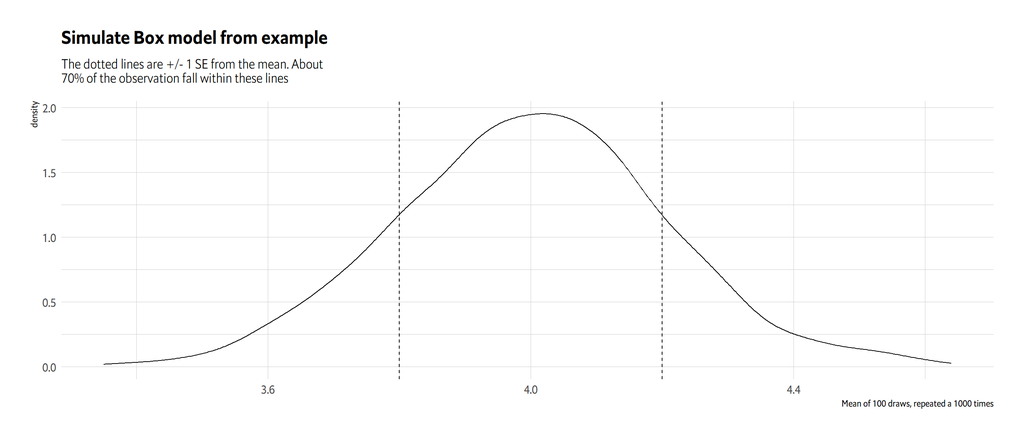

## Example

In a large sample average height for men is 69 inches, the sd for it is 3 inches. What percentage of observation would be within the range 63inches and 72 inches.